# Risk Factor Analysis

## Outcome Variable

**Outcome Variable:** ever_wasted

## Predictor Variables

**Intervention Variable:** birthlen

**Adjustment Set:**

- arm
- sex
- W_mage
- meducyrs
- feducyrs
- vagbrth
- single
- brthmon
- W_parity
- delta_W_mage
- delta_meducyrs
- delta_feducyrs
- delta_vagbrth
- delta_single
- delta_brthmon
- delta_W_parity

## Stratifying Variables

The analysis was stratified on these variable(s):

- agecat
- studyid
- country

## Data Summary

| agecat | studyid | country | birthlen | ever_wasted | n_cell | n |
| --- | --- | --- | --- | --- | --- | --- |
| 0-24 months (no birth wast) | CMC-V-BCS-2002 | INDIA | >=50 cm | 0 | 11 | 104 |
| 0-24 months (no birth wast) | CMC-V-BCS-2002 | INDIA | >=50 cm | 1 | 5 | 104 |
| 0-24 months (no birth wast) | CMC-V-BCS-2002 | INDIA | <48 cm | 0 | 22 | 104 |
| 0-24 months (no birth wast) | CMC-V-BCS-2002 | INDIA | <48 cm | 1 | 26 | 104 |
| 0-24 months (no birth wast) | CMC-V-BCS-2002 | INDIA | [48-50) cm | 0 | 18 | 104 |
| 0-24 months (no birth wast) | CMC-V-BCS-2002 | INDIA | [48-50) cm | 1 | 22 | 104 |
| 0-24 months (no birth wast) | CMIN | BANGLADESH | >=50 cm | 0 | 1 | 17 |
| 0-24 months (no birth wast) | CMIN | BANGLADESH | >=50 cm | 1 | 0 | 17 |
| 0-24 months (no birth wast) | CMIN | BANGLADESH | <48 cm | 0 | 5 | 17 |
| 0-24 months (no birth wast) | CMIN | BANGLADESH | <48 cm | 1 | 3 | 17 |
| 0-24 months (no birth wast) | CMIN | BANGLADESH | [48-50) cm | 0 | 6 | 17 |
| 0-24 months (no birth wast) | CMIN | BANGLADESH | [48-50) cm | 1 | 2 | 17 |
| 0-24 months (no birth wast) | COHORTS | GUATEMALA | >=50 cm | 0 | 382 | 821 |
| 0-24 months (no birth wast) | COHORTS | GUATEMALA | >=50 cm | 1 | 38 | 821 |
| 0-24 months (no birth wast) | COHORTS | GUATEMALA | <48 cm | 0 | 130 | 821 |
| 0-24 months (no birth wast) | COHORTS | GUATEMALA | <48 cm | 1 | 25 | 821 |
| 0-24 months (no birth wast) | COHORTS | GUATEMALA | [48-50) cm | 0 | 219 | 821 |
| 0-24 months (no birth wast) | COHORTS | GUATEMALA | [48-50) cm | 1 | 27 | 821 |
| 0-24 months (no birth wast) | COHORTS | INDIA | >=50 cm | 0 | 1185 | 6400 |
| 0-24 months (no birth wast) | COHORTS | INDIA | >=50 cm | 1 | 204 | 6400 |
| 0-24 months (no birth wast) | COHORTS | INDIA | <48 cm | 0 | 2044 | 6400 |
| 0-24 months (no birth wast) | COHORTS | INDIA | <48 cm | 1 | 600 | 6400 |
| 0-24 months (no birth wast) | COHORTS | INDIA | [48-50) cm | 0 | 1924 | 6400 |
| 0-24 months (no birth wast) | COHORTS | INDIA | [48-50) cm | 1 | 443 | 6400 |
| 0-24 months (no birth wast) | COHORTS | PHILIPPINES | >=50 cm | 0 | 848 | 3011 |
| 0-24 months (no birth wast) | COHORTS | PHILIPPINES | >=50 cm | 1 | 273 | 3011 |
| 0-24 months (no birth wast) | COHORTS | PHILIPPINES | <48 cm | 0 | 454 | 3011 |
| 0-24 months (no birth wast) | COHORTS | PHILIPPINES | <48 cm | 1 | 286 | 3011 |
| 0-24 months (no birth wast) | COHORTS | PHILIPPINES | [48-50) cm | 0 | 795 | 3011 |
| 0-24 months (no birth wast) | COHORTS | PHILIPPINES | [48-50) cm | 1 | 355 | 3011 |

[output cut: 438 more lines]

The following strata were considered:

- agecat: 0-24 months (no birth wast), studyid: CMC-V-BCS-2002, country: INDIA
- agecat: 0-24 months (no birth wast), studyid: CMIN, country: BANGLADESH
- agecat: 0-24 months (no birth wast), studyid: COHORTS, country: GUATEMALA
- agecat: 0-24 months (no birth wast), studyid: COHORTS, country: INDIA
- agecat: 0-24 months (no birth wast), studyid: COHORTS, country: PHILIPPINES
- agecat: 0-24 months (no birth wast), studyid: CONTENT, country: PERU
- agecat: 0-24 months (no birth wast), studyid: EE, country: PAKISTAN
- agecat: 0-24 months (no birth wast), studyid: GMS-Nepal, country: NEPAL
- agecat: 0-24 months (no birth wast), studyid: IRC, country: INDIA
- agecat: 0-24 months (no birth wast), studyid: JiVitA-3, country: BANGLADESH
- agecat: 0-24 months (no birth wast), studyid: JiVitA-4, country: BANGLADESH
- agecat: 0-24 months (no birth wast), studyid: Keneba, country: GAMBIA
- agecat: 0-24 months (no birth wast), studyid: MAL-ED, country: BANGLADESH
- agecat: 0-24 months (no birth wast), studyid: MAL-ED, country: BRAZIL
- agecat: 0-24 months (no birth wast), studyid: MAL-ED, country: INDIA
- agecat: 0-24 months (no birth wast), studyid: MAL-ED, country: NEPAL
- agecat: 0-24 months (no birth wast), studyid: MAL-ED, country: PERU
- agecat: 0-24 months (no birth wast), studyid: MAL-ED, country: SOUTH AFRICA
- agecat: 0-24 months (no birth wast), studyid: MAL-ED, country: TANZANIA, UNITED REPUBLIC OF
- agecat: 0-24 months (no birth wast), studyid: NIH-Birth, country: BANGLADESH
- agecat: 0-24 months (no birth wast), studyid: NIH-Crypto, country: BANGLADESH
- agecat: 0-24 months (no birth wast), studyid: PROBIT, country: BELARUS
- agecat: 0-24 months (no birth wast), studyid: PROVIDE, country: BANGLADESH
- agecat: 0-24 months (no birth wast), studyid: ResPak, country: PAKISTAN
- agecat: 0-24 months (no birth wast), studyid: SAS-CompFeed, country: INDIA
- agecat: 0-24 months (no birth wast), studyid: ZVITAMBO, country: ZIMBABWE
- agecat: 0-6 months (no birth wast), studyid: CMC-V-BCS-2002, country: INDIA
- agecat: 0-6 months (no birth wast), studyid: CMIN, country: BANGLADESH
- agecat: 0-6 months (no birth wast), studyid: COHORTS, country: GUATEMALA
- agecat: 0-6 months (no birth wast), studyid: COHORTS, country: INDIA
- agecat: 0-6 months (no birth wast), studyid: COHORTS, country: PHILIPPINES
- agecat: 0-6 months (no birth wast), studyid: CONTENT, country: PERU
- agecat: 0-6 months (no birth wast), studyid: EE, country: PAKISTAN
- agecat: 0-6 months (no birth wast), studyid: GMS-Nepal, country: NEPAL
- agecat: 0-6 months (no birth wast), studyid: IRC, country: INDIA
- agecat: 0-6 months (no birth wast), studyid: JiVitA-3, country: BANGLADESH
- agecat: 0-6 months (no birth wast), studyid: JiVitA-4, country: BANGLADESH
- agecat: 0-6 months (no birth wast), studyid: Keneba, country: GAMBIA
- agecat: 0-6 months (no birth wast), studyid: MAL-ED, country: BANGLADESH
- agecat: 0-6 months (no birth wast), studyid: MAL-ED, country: BRAZIL
- agecat: 0-6 months (no birth wast), studyid: MAL-ED, country: INDIA
- agecat: 0-6 months (no birth wast), studyid: MAL-ED, country: NEPAL
- agecat: 0-6 months (no birth wast), studyid: MAL-ED, country: PERU
- agecat: 0-6 months (no birth wast), studyid: MAL-ED, country: SOUTH AFRICA
- agecat: 0-6 months (no birth wast), studyid: MAL-ED, country: TANZANIA, UNITED REPUBLIC OF
- agecat: 0-6 months (no birth wast), studyid: NIH-Birth, country: BANGLADESH
- agecat: 0-6 months (no birth wast), studyid: NIH-Crypto, country: BANGLADESH
- agecat: 0-6 months (no birth wast), studyid: PROBIT, country: BELARUS
- agecat: 0-6 months (no birth wast), studyid: PROVIDE, country: BANGLADESH
- agecat: 0-6 months (no birth wast), studyid: ResPak, country: PAKISTAN
- agecat: 0-6 months (no birth wast), studyid: SAS-CompFeed, country: INDIA
- agecat: 0-6 months (no birth wast), studyid: ZVITAMBO, country: ZIMBABWE
- agecat: 6-24 months, studyid: CMC-V-BCS-2002, country: INDIA
- agecat: 6-24 months, studyid: CMIN, country: BANGLADESH
- agecat: 6-24 months, studyid: COHORTS, country: GUATEMALA
- agecat: 6-24 months, studyid: COHORTS, country: INDIA
- agecat: 6-24 months, studyid: COHORTS, country: PHILIPPINES
- agecat: 6-24 months, studyid: CONTENT, country: PERU
- agecat: 6-24 months, studyid: EE, country: PAKISTAN
- agecat: 6-24 months, studyid: GMS-Nepal, country: NEPAL
- agecat: 6-24 months, studyid: IRC, country: INDIA
- agecat: 6-24 months, studyid: JiVitA-3, country: BANGLADESH
- agecat: 6-24 months, studyid: JiVitA-4, country: BANGLADESH
- agecat: 6-24 months, studyid: Keneba, country: GAMBIA
- agecat: 6-24 months, studyid: MAL-ED, country: BANGLADESH
- agecat: 6-24 months, studyid: MAL-ED, country: BRAZIL
- agecat: 6-24 months, studyid: MAL-ED, country: INDIA
- agecat: 6-24 months, studyid: MAL-ED, country: NEPAL
- agecat: 6-24 months, studyid: MAL-ED, country: PERU
- agecat: 6-24 months, studyid: MAL-ED, country: SOUTH AFRICA
- agecat: 6-24 months, studyid: MAL-ED, country: TANZANIA, UNITED REPUBLIC OF
- agecat: 6-24 months, studyid: NIH-Birth, country: BANGLADESH
- agecat: 6-24 months, studyid: NIH-Crypto, country: BANGLADESH
- agecat: 6-24 months, studyid: PROBIT, country: BELARUS
- agecat: 6-24 months, studyid: PROVIDE, country: BANGLADESH
- agecat: 6-24 months, studyid: ResPak, country: PAKISTAN
- agecat: 6-24 months, studyid: SAS-CompFeed, country: INDIA
- agecat: 6-24 months, studyid: ZVITAMBO, country: ZIMBABWE

### Dropped Strata

Some strata were dropped due to rare outcomes:

- agecat: 0-24 months (no birth wast), studyid: CMIN, country: BANGLADESH
- agecat: 0-24 months (no birth wast), studyid: CONTENT, country: PERU
- agecat: 0-24 months (no birth wast), studyid: MAL-ED, country: BRAZIL
- agecat: 0-24 months (no birth wast), studyid: MAL-ED, country: INDIA
- agecat: 0-24 months (no birth wast), studyid: MAL-ED, country: NEPAL
- agecat: 0-24 months (no birth wast), studyid: MAL-ED, country: PERU
- agecat: 0-24 months (no birth wast), studyid: MAL-ED, country: SOUTH AFRICA
- agecat: 0-24 months (no birth wast), studyid: MAL-ED, country: TANZANIA, UNITED REPUBLIC OF
- agecat: 0-6 months (no birth wast), studyid: CMIN, country: BANGLADESH
- agecat: 0-6 months (no birth wast), studyid: CONTENT, country: PERU
- agecat: 0-6 months (no birth wast), studyid: MAL-ED, country: BANGLADESH
- agecat: 0-6 months (no birth wast), studyid: MAL-ED, country: BRAZIL
- agecat: 0-6 months (no birth wast), studyid: MAL-ED, country: INDIA
- agecat: 0-6 months (no birth wast), studyid: MAL-ED, country: NEPAL
- agecat: 0-6 months (no birth wast), studyid: MAL-ED, country: PERU
- agecat: 0-6 months (no birth wast), studyid: MAL-ED, country: SOUTH AFRICA
- agecat: 0-6 months (no birth wast), studyid: MAL-ED, country: TANZANIA, UNITED REPUBLIC OF
- agecat: 0-6 months (no birth wast), studyid: ResPak, country: PAKISTAN
- agecat: 6-24 months, studyid: CMC-V-BCS-2002, country: INDIA
- agecat: 6-24 months, studyid: CMIN, country: BANGLADESH
- agecat: 6-24 months, studyid: CONTENT, country: PERU
- agecat: 6-24 months, studyid: MAL-ED, country: BRAZIL
- agecat: 6-24 months, studyid: MAL-ED, country: INDIA
- agecat: 6-24 months, studyid: MAL-ED, country: NEPAL
- agecat: 6-24 months, studyid: MAL-ED, country: PERU
- agecat: 6-24 months, studyid: MAL-ED, country: SOUTH AFRICA
- agecat: 6-24 months, studyid: MAL-ED, country: TANZANIA, UNITED REPUBLIC OF
- agecat: 6-24 months, studyid: PROBIT, country: BELARUS
- agecat: 6-24 months, studyid: ResPak, country: PAKISTAN

## Methods Detail

We’re interested in the causal parameters $E[Y_a]$ for all values of $a \in \mathcal{A}$. These parameters represent the mean outcome if, possibly contrary to fact, we intervened to set all units to have $A=a$. Under the randomization and positivity assumptions, these are identified by the statistical parameters $\psi_a=E_W[E_{Y|A,W}(Y|A=a,W)]$. In addition, we’re interested in the mean of $Y$, $E[Y]$ under no intervention (the observed mean). We will estimate these parameters by using SuperLearner to fit the relevant likelihood factors – $E_{Y|A,W}(Y|A=a,W)$ and $p(A=a|W)$, and then updating our likelihood fit using a joint TMLE.

For unadjusted analyses ($W=\{\}$), initial likelihoods were estimated using Lrnr_glm to estimate the simple $E(Y|A)$ and Lrnr_mean to estimate $p(A)$. For adjusted analyses, a small library containing Lrnr_glmnet, Lrnr_xgboost, and Lrnr_mean was used.

Having estimated these parameters, we will then use the delta method to estimate relative risks and attributable risks relative to a prespecified baseline level of $A$.

# Results Detail

## Results Plots

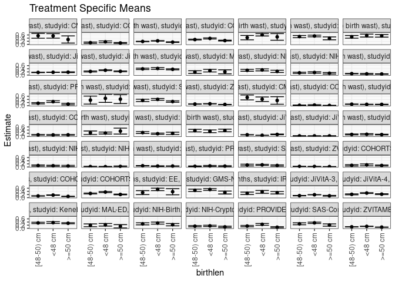

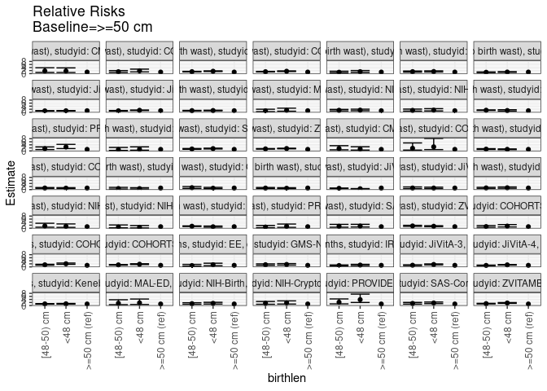

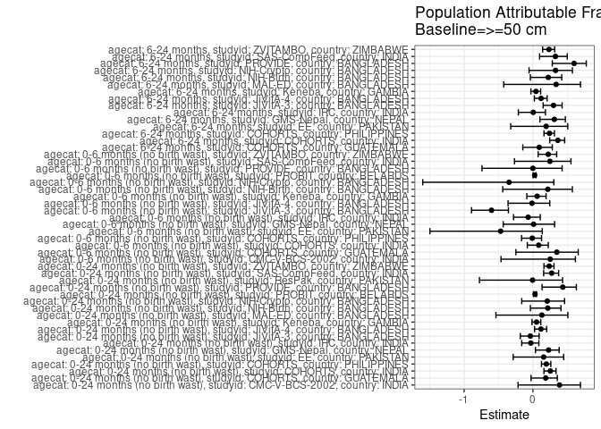

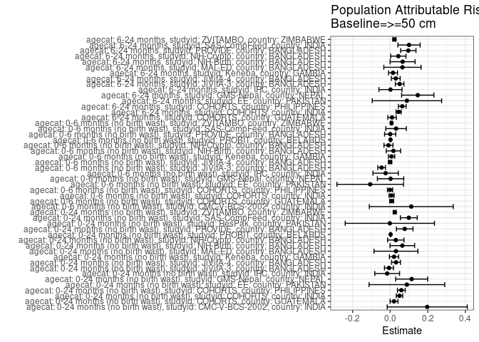

## Results Table

### Parameter: TSM

| agecat | studyid | country | intervention_level | baseline_level | estimate | ci_lower | ci_upper |
| --- | --- | --- | --- | --- | --- | --- | --- |
| 0-24 months (no birth wast) | CMC-V-BCS-2002 | INDIA | >=50 cm | NA | 0.3125000 | 0.0842832 | 0.5407168 |
| 0-24 months (no birth wast) | CMC-V-BCS-2002 | INDIA | <48 cm | NA | 0.5416667 | 0.4000278 | 0.6833055 |
| 0-24 months (no birth wast) | CMC-V-BCS-2002 | INDIA | [48-50) cm | NA | 0.5500000 | 0.3950813 | 0.7049187 |
| 0-24 months (no birth wast) | COHORTS | GUATEMALA | >=50 cm | NA | 0.0892893 | 0.0617857 | 0.1167928 |
| 0-24 months (no birth wast) | COHORTS | GUATEMALA | <48 cm | NA | 0.1640376 | 0.1055593 | 0.2225159 |
| 0-24 months (no birth wast) | COHORTS | GUATEMALA | [48-50) cm | NA | 0.1109736 | 0.0717482 | 0.1501990 |
| 0-24 months (no birth wast) | COHORTS | INDIA | >=50 cm | NA | 0.1455227 | 0.1268309 | 0.1642145 |
| 0-24 months (no birth wast) | COHORTS | INDIA | <48 cm | NA | 0.2267679 | 0.2107744 | 0.2427615 |
| 0-24 months (no birth wast) | COHORTS | INDIA | [48-50) cm | NA | 0.1867681 | 0.1709253 | 0.2026109 |
| 0-24 months (no birth wast) | COHORTS | PHILIPPINES | >=50 cm | NA | 0.2443156 | 0.2193175 | 0.2693136 |
| 0-24 months (no birth wast) | COHORTS | PHILIPPINES | <48 cm | NA | 0.3800801 | 0.3450564 | 0.4151038 |
| 0-24 months (no birth wast) | COHORTS | PHILIPPINES | [48-50) cm | NA | 0.3084942 | 0.2817517 | 0.3352367 |
| 0-24 months (no birth wast) | EE | PAKISTAN | >=50 cm | NA | 0.4778496 | 0.2657854 | 0.6899138 |
| 0-24 months (no birth wast) | EE | PAKISTAN | <48 cm | NA | 0.6102486 | 0.5350849 | 0.6854123 |
| 0-24 months (no birth wast) | EE | PAKISTAN | [48-50) cm | NA | 0.4303598 | 0.2924433 | 0.5682763 |
| 0-24 months (no birth wast) | GMS-Nepal | NEPAL | >=50 cm | NA | 0.3865292 | 0.2937367 | 0.4793218 |
| 0-24 months (no birth wast) | GMS-Nepal | NEPAL | <48 cm | NA | 0.5363453 | 0.4839685 | 0.5887220 |
| 0-24 months (no birth wast) | GMS-Nepal | NEPAL | [48-50) cm | NA | 0.4969344 | 0.4274804 | 0.5663884 |
| 0-24 months (no birth wast) | IRC | INDIA | >=50 cm | NA | 0.5469069 | 0.4643642 | 0.6294496 |
| 0-24 months (no birth wast) | IRC | INDIA | <48 cm | NA | 0.5637960 | 0.4708344 | 0.6567577 |
| 0-24 months (no birth wast) | IRC | INDIA | [48-50) cm | NA | 0.4807985 | 0.3967455 | 0.5648516 |
| 0-24 months (no birth wast) | JiVitA-3 | BANGLADESH | >=50 cm | NA | 0.1822824 | 0.1578182 | 0.2067465 |
| 0-24 months (no birth wast) | JiVitA-3 | BANGLADESH | <48 cm | NA | 0.1773691 | 0.1705705 | 0.1841678 |
| 0-24 months (no birth wast) | JiVitA-3 | BANGLADESH | [48-50) cm | NA | 0.1678792 | 0.1551556 | 0.1806028 |
| 0-24 months (no birth wast) | JiVitA-4 | BANGLADESH | >=50 cm | NA | 0.2353383 | 0.2087520 | 0.2619247 |
| 0-24 months (no birth wast) | JiVitA-4 | BANGLADESH | <48 cm | NA | 0.3074414 | 0.2835217 | 0.3313612 |
| 0-24 months (no birth wast) | JiVitA-4 | BANGLADESH | [48-50) cm | NA | 0.2275949 | 0.1963375 | 0.2588523 |
| 0-24 months (no birth wast) | Keneba | GAMBIA | >=50 cm | NA | 0.3661288 | 0.3319225 | 0.4003351 |
| 0-24 months (no birth wast) | Keneba | GAMBIA | <48 cm | NA | 0.4179127 | 0.3617988 | 0.4740267 |
| 0-24 months (no birth wast) | Keneba | GAMBIA | [48-50) cm | NA | 0.3936775 | 0.3498596 | 0.4374954 |

[output cut: 117 more lines]

### Parameter: E(Y)

| agecat | studyid | country | intervention_level | baseline_level | estimate | ci_lower | ci_upper |
| --- | --- | --- | --- | --- | --- | --- | --- |
| 0-24 months (no birth wast) | CMC-V-BCS-2002 | INDIA | NA | NA | 0.5096154 | 0.4130727 | 0.6061580 |
| 0-24 months (no birth wast) | COHORTS | GUATEMALA | NA | NA | 0.1096224 | 0.0882390 | 0.1310059 |
| 0-24 months (no birth wast) | COHORTS | INDIA | NA | NA | 0.1948438 | 0.1851392 | 0.2045483 |
| 0-24 months (no birth wast) | COHORTS | PHILIPPINES | NA | NA | 0.3035536 | 0.2871278 | 0.3199794 |
| 0-24 months (no birth wast) | EE | PAKISTAN | NA | NA | 0.5666667 | 0.5038429 | 0.6294904 |
| 0-24 months (no birth wast) | GMS-Nepal | NEPAL | NA | NA | 0.5007587 | 0.4625551 | 0.5389624 |
| 0-24 months (no birth wast) | IRC | INDIA | NA | NA | 0.5307692 | 0.4811763 | 0.5803621 |
| 0-24 months (no birth wast) | JiVitA-3 | BANGLADESH | NA | NA | 0.1757133 | 0.1696451 | 0.1817815 |
| 0-24 months (no birth wast) | JiVitA-4 | BANGLADESH | NA | NA | 0.2663530 | 0.2512746 | 0.2814315 |
| 0-24 months (no birth wast) | Keneba | GAMBIA | NA | NA | 0.3865546 | 0.3622809 | 0.4108284 |
| 0-24 months (no birth wast) | MAL-ED | BANGLADESH | NA | NA | 0.2358079 | 0.1807067 | 0.2909091 |
| 0-24 months (no birth wast) | NIH-Birth | BANGLADESH | NA | NA | 0.2977625 | 0.2605481 | 0.3349769 |
| 0-24 months (no birth wast) | NIH-Crypto | BANGLADESH | NA | NA | 0.1432361 | 0.1182149 | 0.1682572 |
| 0-24 months (no birth wast) | PROBIT | BELARUS | NA | NA | 0.0680135 | 0.0562135 | 0.0798135 |
| 0-24 months (no birth wast) | PROVIDE | BANGLADESH | NA | NA | 0.1775837 | 0.1489858 | 0.2061816 |
| 0-24 months (no birth wast) | ResPak | PAKISTAN | NA | NA | 0.4146341 | 0.2619604 | 0.5673079 |
| 0-24 months (no birth wast) | SAS-CompFeed | INDIA | NA | NA | 0.3626595 | 0.3120201 | 0.4132989 |
| 0-24 months (no birth wast) | ZVITAMBO | ZIMBABWE | NA | NA | 0.1019924 | 0.0968873 | 0.1070976 |
| 0-6 months (no birth wast) | CMC-V-BCS-2002 | INDIA | NA | NA | 0.4455446 | 0.3481293 | 0.5429598 |
| 0-6 months (no birth wast) | COHORTS | GUATEMALA | NA | NA | 0.0226986 | 0.0123257 | 0.0330715 |
| 0-6 months (no birth wast) | COHORTS | INDIA | NA | NA | 0.0882353 | 0.0810887 | 0.0953819 |
| 0-6 months (no birth wast) | COHORTS | PHILIPPINES | NA | NA | 0.0946488 | 0.0841546 | 0.1051431 |
| 0-6 months (no birth wast) | EE | PAKISTAN | NA | NA | 0.2268908 | 0.1735692 | 0.2802123 |
| 0-6 months (no birth wast) | GMS-Nepal | NEPAL | NA | NA | 0.1918877 | 0.1613794 | 0.2223959 |
| 0-6 months (no birth wast) | IRC | INDIA | NA | NA | 0.3494624 | 0.3009450 | 0.3979798 |
| 0-6 months (no birth wast) | JiVitA-3 | BANGLADESH | NA | NA | 0.0760414 | 0.0718411 | 0.0802418 |
| 0-6 months (no birth wast) | JiVitA-4 | BANGLADESH | NA | NA | 0.0289057 | 0.0236101 | 0.0342013 |
| 0-6 months (no birth wast) | Keneba | GAMBIA | NA | NA | 0.1187215 | 0.1025243 | 0.1349187 |
| 0-6 months (no birth wast) | NIH-Birth | BANGLADESH | NA | NA | 0.0797872 | 0.0574049 | 0.1021695 |
| 0-6 months (no birth wast) | NIH-Crypto | BANGLADESH | NA | NA | 0.0267023 | 0.0151493 | 0.0382553 |
| 0-6 months (no birth wast) | PROBIT | BELARUS | NA | NA | 0.0612233 | 0.0502388 | 0.0722078 |
| 0-6 months (no birth wast) | PROVIDE | BANGLADESH | NA | NA | 0.0541728 | 0.0371844 | 0.0711612 |
| 0-6 months (no birth wast) | SAS-CompFeed | INDIA | NA | NA | 0.1264525 | 0.0961151 | 0.1567899 |
| 0-6 months (no birth wast) | ZVITAMBO | ZIMBABWE | NA | NA | 0.0322167 | 0.0292105 | 0.0352229 |
| 6-24 months | COHORTS | GUATEMALA | NA | NA | 0.1059147 | 0.0835302 | 0.1282992 |
| 6-24 months | COHORTS | INDIA | NA | NA | 0.1236829 | 0.1154669 | 0.1318989 |
| 6-24 months | COHORTS | PHILIPPINES | NA | NA | 0.2665953 | 0.2502200 | 0.2829706 |
| 6-24 months | EE | PAKISTAN | NA | NA | 0.4641350 | 0.4005079 | 0.5277621 |
| 6-24 months | GMS-Nepal | NEPAL | NA | NA | 0.4719864 | 0.4316361 | 0.5123367 |
| 6-24 months | IRC | INDIA | NA | NA | 0.3145780 | 0.2684931 | 0.3606629 |
| 6-24 months | JiVitA-3 | BANGLADESH | NA | NA | 0.1671558 | 0.1603545 | 0.1739571 |
| 6-24 months | JiVitA-4 | BANGLADESH | NA | NA | 0.2510058 | 0.2361044 | 0.2659072 |
| 6-24 months | Keneba | GAMBIA | NA | NA | 0.3362475 | 0.3122276 | 0.3602674 |
| 6-24 months | MAL-ED | BANGLADESH | NA | NA | 0.1933962 | 0.1401044 | 0.2466881 |
| 6-24 months | NIH-Birth | BANGLADESH | NA | NA | 0.2950192 | 0.2558591 | 0.3341792 |
| 6-24 months | NIH-Crypto | BANGLADESH | NA | NA | 0.1315068 | 0.1069744 | 0.1560393 |
| 6-24 months | PROVIDE | BANGLADESH | NA | NA | 0.1609756 | 0.1319065 | 0.1900447 |
| 6-24 months | SAS-CompFeed | INDIA | NA | NA | 0.3059593 | 0.2629068 | 0.3490118 |
| 6-24 months | ZVITAMBO | ZIMBABWE | NA | NA | 0.0956969 | 0.0901201 | 0.1012737 |

### Parameter: RR

| agecat | studyid | country | intervention_level | baseline_level | estimate | ci_lower | ci_upper |
| --- | --- | --- | --- | --- | --- | --- | --- |
| 0-24 months (no birth wast) | CMC-V-BCS-2002 | INDIA | >=50 cm | >=50 cm | 1.0000000 | 1.0000000 | 1.0000000 |
| 0-24 months (no birth wast) | CMC-V-BCS-2002 | INDIA | <48 cm | >=50 cm | 1.7333333 | 0.7979976 | 3.7649791 |
| 0-24 months (no birth wast) | CMC-V-BCS-2002 | INDIA | [48-50) cm | >=50 cm | 1.7600000 | 0.8045947 | 3.8498887 |
| 0-24 months (no birth wast) | COHORTS | GUATEMALA | >=50 cm | >=50 cm | 1.0000000 | 1.0000000 | 1.0000000 |
| 0-24 months (no birth wast) | COHORTS | GUATEMALA | <48 cm | >=50 cm | 1.8371476 | 1.1472863 | 2.9418212 |
| 0-24 months (no birth wast) | COHORTS | GUATEMALA | [48-50) cm | >=50 cm | 1.2428543 | 0.7776224 | 1.9864229 |
| 0-24 months (no birth wast) | COHORTS | INDIA | >=50 cm | >=50 cm | 1.0000000 | 1.0000000 | 1.0000000 |
| 0-24 months (no birth wast) | COHORTS | INDIA | <48 cm | >=50 cm | 1.5582999 | 1.3462411 | 1.8037619 |
| 0-24 months (no birth wast) | COHORTS | INDIA | [48-50) cm | >=50 cm | 1.2834295 | 1.1005987 | 1.4966320 |
| 0-24 months (no birth wast) | COHORTS | PHILIPPINES | >=50 cm | >=50 cm | 1.0000000 | 1.0000000 | 1.0000000 |
| 0-24 months (no birth wast) | COHORTS | PHILIPPINES | <48 cm | >=50 cm | 1.5556932 | 1.3560840 | 1.7846840 |
| 0-24 months (no birth wast) | COHORTS | PHILIPPINES | [48-50) cm | >=50 cm | 1.2626876 | 1.1047160 | 1.4432488 |
| 0-24 months (no birth wast) | EE | PAKISTAN | >=50 cm | >=50 cm | 1.0000000 | 1.0000000 | 1.0000000 |
| 0-24 months (no birth wast) | EE | PAKISTAN | <48 cm | >=50 cm | 1.2770727 | 0.8061549 | 2.0230783 |
| 0-24 months (no birth wast) | EE | PAKISTAN | [48-50) cm | >=50 cm | 0.9006177 | 0.5220599 | 1.5536766 |
| 0-24 months (no birth wast) | GMS-Nepal | NEPAL | >=50 cm | >=50 cm | 1.0000000 | 1.0000000 | 1.0000000 |
| 0-24 months (no birth wast) | GMS-Nepal | NEPAL | <48 cm | >=50 cm | 1.3875931 | 1.0704858 | 1.7986365 |
| 0-24 months (no birth wast) | GMS-Nepal | NEPAL | [48-50) cm | >=50 cm | 1.2856323 | 0.9744575 | 1.6961749 |
| 0-24 months (no birth wast) | IRC | INDIA | >=50 cm | >=50 cm | 1.0000000 | 1.0000000 | 1.0000000 |
| 0-24 months (no birth wast) | IRC | INDIA | <48 cm | >=50 cm | 1.0308812 | 0.8243414 | 1.2891698 |
| 0-24 months (no birth wast) | IRC | INDIA | [48-50) cm | >=50 cm | 0.8791232 | 0.6977281 | 1.1076773 |
| 0-24 months (no birth wast) | JiVitA-3 | BANGLADESH | >=50 cm | >=50 cm | 1.0000000 | 1.0000000 | 1.0000000 |
| 0-24 months (no birth wast) | JiVitA-3 | BANGLADESH | <48 cm | >=50 cm | 0.9730461 | 0.8464939 | 1.1185180 |
| 0-24 months (no birth wast) | JiVitA-3 | BANGLADESH | [48-50) cm | >=50 cm | 0.9209844 | 0.7905593 | 1.0729269 |
| 0-24 months (no birth wast) | JiVitA-4 | BANGLADESH | >=50 cm | >=50 cm | 1.0000000 | 1.0000000 | 1.0000000 |
| 0-24 months (no birth wast) | JiVitA-4 | BANGLADESH | <48 cm | >=50 cm | 1.3063806 | 1.1415613 | 1.4949967 |
| 0-24 months (no birth wast) | JiVitA-4 | BANGLADESH | [48-50) cm | >=50 cm | 0.9670965 | 0.8098668 | 1.1548511 |
| 0-24 months (no birth wast) | Keneba | GAMBIA | >=50 cm | >=50 cm | 1.0000000 | 1.0000000 | 1.0000000 |
| 0-24 months (no birth wast) | Keneba | GAMBIA | <48 cm | >=50 cm | 1.1414363 | 0.9699611 | 1.3432260 |
| 0-24 months (no birth wast) | Keneba | GAMBIA | [48-50) cm | >=50 cm | 1.0752431 | 0.9301847 | 1.2429228 |

[output cut: 117 more lines]

### Parameter: PAR

| agecat | studyid | country | intervention_level | baseline_level | estimate | ci_lower | ci_upper |
| --- | --- | --- | --- | --- | --- | --- | --- |
| 0-24 months (no birth wast) | CMC-V-BCS-2002 | INDIA | >=50 cm | NA | 0.1971154 | -0.0159054 | 0.4101362 |
| 0-24 months (no birth wast) | COHORTS | GUATEMALA | >=50 cm | NA | 0.0203331 | -0.0006660 | 0.0413322 |
| 0-24 months (no birth wast) | COHORTS | INDIA | >=50 cm | NA | 0.0493211 | 0.0321606 | 0.0664815 |
| 0-24 months (no birth wast) | COHORTS | PHILIPPINES | >=50 cm | NA | 0.0592381 | 0.0385770 | 0.0798992 |
| 0-24 months (no birth wast) | EE | PAKISTAN | >=50 cm | NA | 0.0888171 | -0.1124931 | 0.2901273 |
| 0-24 months (no birth wast) | GMS-Nepal | NEPAL | >=50 cm | NA | 0.1142295 | 0.0288938 | 0.1995652 |
| 0-24 months (no birth wast) | IRC | INDIA | >=50 cm | NA | -0.0161377 | -0.0821023 | 0.0498269 |
| 0-24 months (no birth wast) | JiVitA-3 | BANGLADESH | >=50 cm | NA | -0.0065691 | -0.0305185 | 0.0173804 |
| 0-24 months (no birth wast) | JiVitA-4 | BANGLADESH | >=50 cm | NA | 0.0310147 | 0.0075980 | 0.0544314 |
| 0-24 months (no birth wast) | Keneba | GAMBIA | >=50 cm | NA | 0.0204258 | -0.0041486 | 0.0450001 |
| 0-24 months (no birth wast) | MAL-ED | BANGLADESH | >=50 cm | NA | 0.0306797 | -0.0862501 | 0.1476095 |
| 0-24 months (no birth wast) | NIH-Birth | BANGLADESH | >=50 cm | NA | 0.0644026 | -0.0010279 | 0.1298330 |
| 0-24 months (no birth wast) | NIH-Crypto | BANGLADESH | >=50 cm | NA | 0.0297722 | -0.0139360 | 0.0734804 |
| 0-24 months (no birth wast) | PROBIT | BELARUS | >=50 cm | NA | 0.0020986 | 0.0007655 | 0.0034317 |
| 0-24 months (no birth wast) | PROVIDE | BANGLADESH | >=50 cm | NA | 0.0771861 | 0.0330609 | 0.1213112 |
| 0-24 months (no birth wast) | ResPak | PAKISTAN | >=50 cm | NA | -0.0020325 | -0.2394717 | 0.2354067 |
| 0-24 months (no birth wast) | SAS-CompFeed | INDIA | >=50 cm | NA | 0.0989575 | 0.0540231 | 0.1438920 |
| 0-24 months (no birth wast) | ZVITAMBO | ZIMBABWE | >=50 cm | NA | 0.0241342 | 0.0166216 | 0.0316469 |
| 0-6 months (no birth wast) | CMC-V-BCS-2002 | INDIA | >=50 cm | NA | 0.1122112 | -0.1111633 | 0.3355858 |
| 0-6 months (no birth wast) | COHORTS | GUATEMALA | >=50 cm | NA | 0.0078838 | -0.0023448 | 0.0181124 |
| 0-6 months (no birth wast) | COHORTS | INDIA | >=50 cm | NA | 0.0073647 | -0.0060143 | 0.0207436 |
| 0-6 months (no birth wast) | COHORTS | PHILIPPINES | >=50 cm | NA | -0.0008685 | -0.0145710 | 0.0128340 |
| 0-6 months (no birth wast) | EE | PAKISTAN | >=50 cm | NA | -0.1064426 | -0.2835258 | 0.0706407 |
| 0-6 months (no birth wast) | GMS-Nepal | NEPAL | >=50 cm | NA | 0.0019504 | -0.0681391 | 0.0720399 |
| 0-6 months (no birth wast) | IRC | INDIA | >=50 cm | NA | -0.0243044 | -0.0917296 | 0.0431208 |
| 0-6 months (no birth wast) | JiVitA-3 | BANGLADESH | >=50 cm | NA | -0.0457544 | -0.0660456 | -0.0254632 |
| 0-6 months (no birth wast) | JiVitA-4 | BANGLADESH | >=50 cm | NA | -0.0003897 | -0.0090274 | 0.0082481 |
| 0-6 months (no birth wast) | Keneba | GAMBIA | >=50 cm | NA | 0.0073462 | -0.0092094 | 0.0239019 |
| 0-6 months (no birth wast) | NIH-Birth | BANGLADESH | >=50 cm | NA | 0.0172872 | -0.0209617 | 0.0555361 |
| 0-6 months (no birth wast) | NIH-Crypto | BANGLADESH | >=50 cm | NA | -0.0092259 | -0.0332159 | 0.0147641 |
| 0-6 months (no birth wast) | PROBIT | BELARUS | >=50 cm | NA | 0.0015114 | 0.0002620 | 0.0027609 |
| 0-6 months (no birth wast) | PROVIDE | BANGLADESH | >=50 cm | NA | -0.0000441 | -0.0300327 | 0.0299445 |
| 0-6 months (no birth wast) | SAS-CompFeed | INDIA | >=50 cm | NA | 0.0312693 | -0.0233813 | 0.0859199 |
| 0-6 months (no birth wast) | ZVITAMBO | ZIMBABWE | >=50 cm | NA | 0.0071649 | 0.0027909 | 0.0115388 |
| 6-24 months | COHORTS | GUATEMALA | >=50 cm | NA | 0.0097569 | -0.0128004 | 0.0323142 |
| 6-24 months | COHORTS | INDIA | >=50 cm | NA | 0.0447871 | 0.0311328 | 0.0584415 |
| 6-24 months | COHORTS | PHILIPPINES | >=50 cm | NA | 0.0641759 | 0.0437857 | 0.0845661 |
| 6-24 months | EE | PAKISTAN | >=50 cm | NA | 0.0891350 | -0.0955041 | 0.2737741 |
| 6-24 months | GMS-Nepal | NEPAL | >=50 cm | NA | 0.1466757 | 0.0607262 | 0.2326252 |
| 6-24 months | IRC | INDIA | >=50 cm | NA | 0.0014820 | -0.0601009 | 0.0630649 |
| 6-24 months | JiVitA-3 | BANGLADESH | >=50 cm | NA | 0.0501450 | 0.0273284 | 0.0729616 |
| 6-24 months | JiVitA-4 | BANGLADESH | >=50 cm | NA | 0.0298321 | 0.0064656 | 0.0531986 |
| 6-24 months | Keneba | GAMBIA | >=50 cm | NA | 0.0148518 | -0.0090704 | 0.0387740 |
| 6-24 months | MAL-ED | BANGLADESH | >=50 cm | NA | 0.0651911 | -0.0339632 | 0.1643454 |
| 6-24 months | NIH-Birth | BANGLADESH | >=50 cm | NA | 0.0659912 | -0.0005418 | 0.1325243 |
| 6-24 months | NIH-Crypto | BANGLADESH | >=50 cm | NA | 0.0433172 | 0.0025817 | 0.0840528 |
| 6-24 months | PROVIDE | BANGLADESH | >=50 cm | NA | 0.0963301 | 0.0555790 | 0.1370811 |
| 6-24 months | SAS-CompFeed | INDIA | >=50 cm | NA | 0.1000884 | 0.0409333 | 0.1592435 |
| 6-24 months | ZVITAMBO | ZIMBABWE | >=50 cm | NA | 0.0223638 | 0.0139531 | 0.0307744 |

### Parameter: PAF

| agecat | studyid | country | intervention_level | baseline_level | estimate | ci_lower | ci_upper |
| --- | --- | --- | --- | --- | --- | --- | --- |
| 0-24 months (no birth wast) | CMC-V-BCS-2002 | INDIA | >=50 cm | NA | 0.3867925 | -0.2158991 | 0.6907445 |
| 0-24 months (no birth wast) | COHORTS | GUATEMALA | >=50 cm | NA | 0.1854834 | -0.0275587 | 0.3543557 |
| 0-24 months (no birth wast) | COHORTS | INDIA | >=50 cm | NA | 0.2531315 | 0.1603148 | 0.3356884 |
| 0-24 months (no birth wast) | COHORTS | PHILIPPINES | >=50 cm | NA | 0.1951486 | 0.1244482 | 0.2601400 |
| 0-24 months (no birth wast) | EE | PAKISTAN | >=50 cm | NA | 0.1567360 | -0.2862326 | 0.4471497 |
| 0-24 months (no birth wast) | GMS-Nepal | NEPAL | >=50 cm | NA | 0.2281129 | 0.0367539 | 0.3814564 |
| 0-24 months (no birth wast) | IRC | INDIA | >=50 cm | NA | -0.0304043 | -0.1625265 | 0.0867021 |
| 0-24 months (no birth wast) | JiVitA-3 | BANGLADESH | >=50 cm | NA | -0.0373851 | -0.1831100 | 0.0903907 |
| 0-24 months (no birth wast) | JiVitA-4 | BANGLADESH | >=50 cm | NA | 0.1164421 | 0.0244413 | 0.1997667 |
| 0-24 months (no birth wast) | Keneba | GAMBIA | >=50 cm | NA | 0.0528406 | -0.0129382 | 0.1143479 |
| 0-24 months (no birth wast) | MAL-ED | BANGLADESH | >=50 cm | NA | 0.1301045 | -0.5374946 | 0.5078238 |
| 0-24 months (no birth wast) | NIH-Birth | BANGLADESH | >=50 cm | NA | 0.2162884 | -0.0364722 | 0.4074092 |
| 0-24 months (no birth wast) | NIH-Crypto | BANGLADESH | >=50 cm | NA | 0.2078539 | -0.1620479 | 0.4600090 |
| 0-24 months (no birth wast) | PROBIT | BELARUS | >=50 cm | NA | 0.0308559 | 0.0101687 | 0.0511107 |
| 0-24 months (no birth wast) | PROVIDE | BANGLADESH | >=50 cm | NA | 0.4346460 | 0.1330947 | 0.6313033 |
| 0-24 months (no birth wast) | ResPak | PAKISTAN | >=50 cm | NA | -0.0049020 | -0.7766780 | 0.4316202 |
| 0-24 months (no birth wast) | SAS-CompFeed | INDIA | >=50 cm | NA | 0.2728662 | 0.1560925 | 0.3734816 |
| 0-24 months (no birth wast) | ZVITAMBO | ZIMBABWE | >=50 cm | NA | 0.2366276 | 0.1601864 | 0.3061110 |
| 0-6 months (no birth wast) | CMC-V-BCS-2002 | INDIA | >=50 cm | NA | 0.2518519 | -0.4634357 | 0.6175263 |
| 0-6 months (no birth wast) | COHORTS | GUATEMALA | >=50 cm | NA | 0.3473251 | -0.2471956 | 0.6584461 |
| 0-6 months (no birth wast) | COHORTS | INDIA | >=50 cm | NA | 0.0834661 | -0.0812570 | 0.2230946 |
| 0-6 months (no birth wast) | COHORTS | PHILIPPINES | >=50 cm | NA | -0.0091761 | -0.1648411 | 0.1256864 |
| 0-6 months (no birth wast) | EE | PAKISTAN | >=50 cm | NA | -0.4691358 | -1.4972590 | 0.1357084 |
| 0-6 months (no birth wast) | GMS-Nepal | NEPAL | >=50 cm | NA | 0.0101644 | -0.4315922 | 0.3156050 |
| 0-6 months (no birth wast) | IRC | INDIA | >=50 cm | NA | -0.0695480 | -0.2809636 | 0.1069746 |
| 0-6 months (no birth wast) | JiVitA-3 | BANGLADESH | >=50 cm | NA | -0.6017032 | -0.8919020 | -0.3560180 |
| 0-6 months (no birth wast) | JiVitA-4 | BANGLADESH | >=50 cm | NA | -0.0134804 | -0.3611008 | 0.2453589 |
| 0-6 months (no birth wast) | Keneba | GAMBIA | >=50 cm | NA | 0.0618779 | -0.0882632 | 0.1913050 |
| 0-6 months (no birth wast) | NIH-Birth | BANGLADESH | >=50 cm | NA | 0.2166667 | -0.4383833 | 0.5734022 |
| 0-6 months (no birth wast) | NIH-Crypto | BANGLADESH | >=50 cm | NA | -0.3455090 | -1.6009534 | 0.3039497 |
| 0-6 months (no birth wast) | PROBIT | BELARUS | >=50 cm | NA | 0.0246869 | 0.0034264 | 0.0454938 |
| 0-6 months (no birth wast) | PROVIDE | BANGLADESH | >=50 cm | NA | -0.0008141 | -0.7400909 | 0.4243813 |
| 0-6 months (no birth wast) | SAS-CompFeed | INDIA | >=50 cm | NA | 0.2472812 | -0.2681419 | 0.5532159 |
| 0-6 months (no birth wast) | ZVITAMBO | ZIMBABWE | >=50 cm | NA | 0.2223961 | 0.0759855 | 0.3456078 |
| 6-24 months | COHORTS | GUATEMALA | >=50 cm | NA | 0.0921199 | -0.1471078 | 0.2814571 |
| 6-24 months | COHORTS | INDIA | >=50 cm | NA | 0.3621126 | 0.2441320 | 0.4616779 |
| 6-24 months | COHORTS | PHILIPPINES | >=50 cm | NA | 0.2407240 | 0.1610892 | 0.3127993 |
| 6-24 months | EE | PAKISTAN | >=50 cm | NA | 0.1920455 | -0.3225373 | 0.5064105 |
| 6-24 months | GMS-Nepal | NEPAL | >=50 cm | NA | 0.3107626 | 0.1015518 | 0.4712570 |
| 6-24 months | IRC | INDIA | >=50 cm | NA | 0.0047112 | -0.2116349 | 0.1824271 |
| 6-24 months | JiVitA-3 | BANGLADESH | >=50 cm | NA | 0.2999894 | 0.1488253 | 0.4243076 |
| 6-24 months | JiVitA-4 | BANGLADESH | >=50 cm | NA | 0.1188503 | 0.0210851 | 0.2068516 |
| 6-24 months | Keneba | GAMBIA | >=50 cm | NA | 0.0441692 | -0.0297039 | 0.1127425 |
| 6-24 months | MAL-ED | BANGLADESH | >=50 cm | NA | 0.3370857 | -0.4241671 | 0.6914299 |
| 6-24 months | NIH-Birth | BANGLADESH | >=50 cm | NA | 0.2236846 | -0.0369308 | 0.4187986 |
| 6-24 months | NIH-Crypto | BANGLADESH | >=50 cm | NA | 0.3293916 | -0.0558795 | 0.5740843 |
| 6-24 months | PROVIDE | BANGLADESH | >=50 cm | NA | 0.5984140 | 0.2813202 | 0.7756006 |
| 6-24 months | SAS-CompFeed | INDIA | >=50 cm | NA | 0.3271298 | 0.0971289 | 0.4985394 |
| 6-24 months | ZVITAMBO | ZIMBABWE | >=50 cm | NA | 0.2336936 | 0.1415844 | 0.3159193 |